# ASCT marker genes analysis

## Context

The performance of scRNAseq classification tools that are based on marker genes (e.g. `scina` or `cellassign`) has not been as good as expected. Whereas `scina` demonstrated good results when self-projecting (using markers derived from given dataset to classify its own cells showed >70% match), running it with ASCT tables or marker genes from CellMarker database showed poor performance. Possible reasons for low accuracy include mismatch of cell types across expression data and marker tables, inaccurate annotations in the Atlas, and incorrectly selected markers in ASCT tables.

The aim of this analysis is to determine how accurate the ASCT markers are using 3 different human gut scRNAseq datasets from SCXA.

## Methods

Three datasets were used: `E-GEOD-125970`, `E-HCAD-11`, and `E-MTAB-8410`. Two separate sources of evidence were used: violin plots and marker gene p-values generated from scanpy.

### Violin plots

Plots were generated for each group of marker genes from ASCT tables across each dataset. The following function from scanpy was used: `sc.pl.violin`.

#### Marker gene p-values

Scanpy command `scanpy-find-markers` was used to generate marker p-values for *all* genes in *each* cell type across the three datasets. In other words, these tables contained all combinations of genes and corresponding cell types, including non-significant hits. The tables were then merged with ASCT markers to keep only the overlapping genes. The resulting tables were inspected to find cases where ASCT markers and marker p-value tables point to the same cell type and whether the result is deemed significant by scanpy.

## Results

Below are shown which genes were matched to SCXA data with high, low, and no specificity (failure to match). Further, the mismatches are shown for genes which are non-significant (shown as `gene name` | `tlas cell type` | `ASCT cell type` | `scanpy p-value`) together with corresponding violin plots.

### E-GEOD-125970

- Matched genes (11): ASCL2, BEST4, BIRC3, CD36, CRYBA2, ITLN1, LGR5, LYZ, MUC2, MYL9, SI.
- Mismatched genes (5): CA7, CDHR1, DEFA5, NEURL1, SLC26A2.
- No match found (20): ACTG2, CA2, CD14, CD2, CD3D, CD4, CD8A, CLCA4, COL6A1, COL6A2, DES, IGLL5, IRF7, MGLL, MKI67, MS4A1, PAX5, SELENBP1, TAGLN, TP53I3.
- BIRC3 | epithelial progenitor cell of small intestine | epithelial stem cells | 0.69

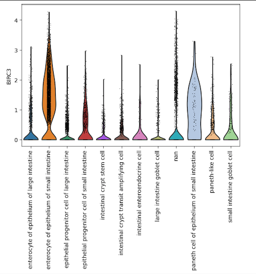

- CA7 | enterocyte of epithelium of large intestine | enterocytes | 0.36

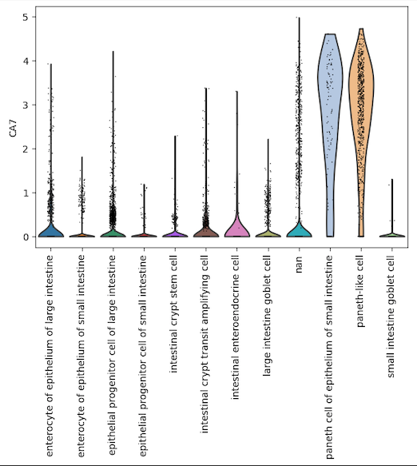

- BEST4 | enterocyte of epithelium of large intestine | enterocytes | 0.065

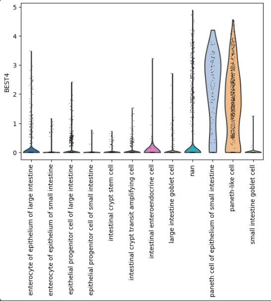

### E-HCAD-11

- Matched genes (8): ACTG2, ASCL2, CA2, CD14, CD2, CD3D, IGLL5, MGLL
- Mismatched genes (5): CD36, CD4, CD8A, MYL9, TAGLN
- No match found (17): BEST4, BIRC3, CA7, CLCA4, COL6A1, COL6A2, DES, IRF7, LGR5, LYZ, MKI67, MS4A1, MUC2, NEURL1, SELENBP1, SI, TP53I3
- TP53I3 | myofibroblast cell | myofibroblasts | 0.24
- DES | myofibroblast cell | myofibroblasts | 0.24

### E-MTAB-8410

- Matched genes (17): ACTG2, ASCL2, BEST4, BIRC3, CA2, CA7, CD14, CD2, CD3D, CDHR1, DES, IGLL5, ITLN1, MS4A1, MUC2, PAX5, SI.
- Mismatched genes (7): BIRC3, CD36, CD4, CD8A, COL6A1, COL6A2, LGR5.
- No match found (13): CLCA4, CRYBA2, DEFA5, IRF7, LYZ, MGLL, MKI67, MYL9, NEURL1, SELENBP1, SLC26A2, TAGLN, TP53I3.

### Incorrect matches:

- PAX5 | plasma cell | B cells | 0.89

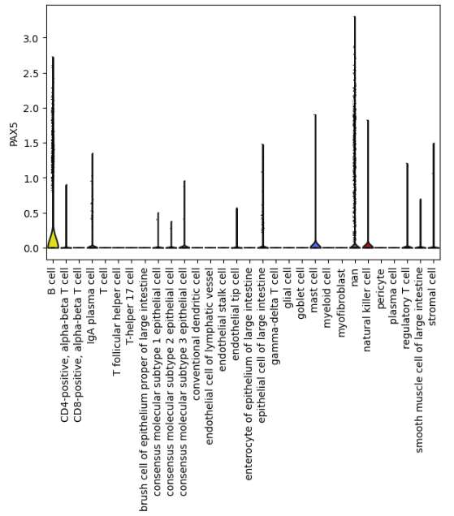

- BEST4 | epithelial cell of large intestine | enterocytes | 0.82

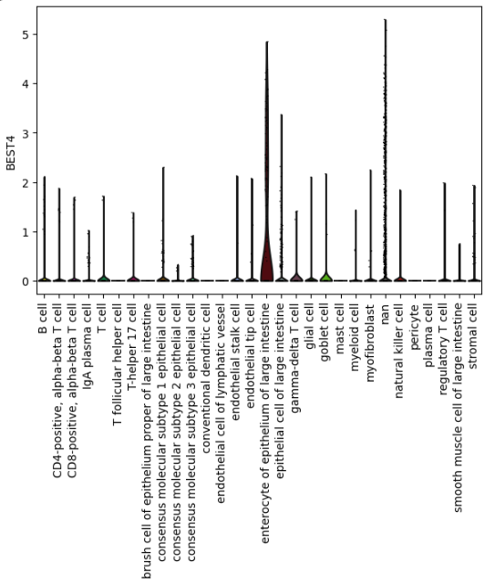

- CLCA4 | goblet cell | goblet

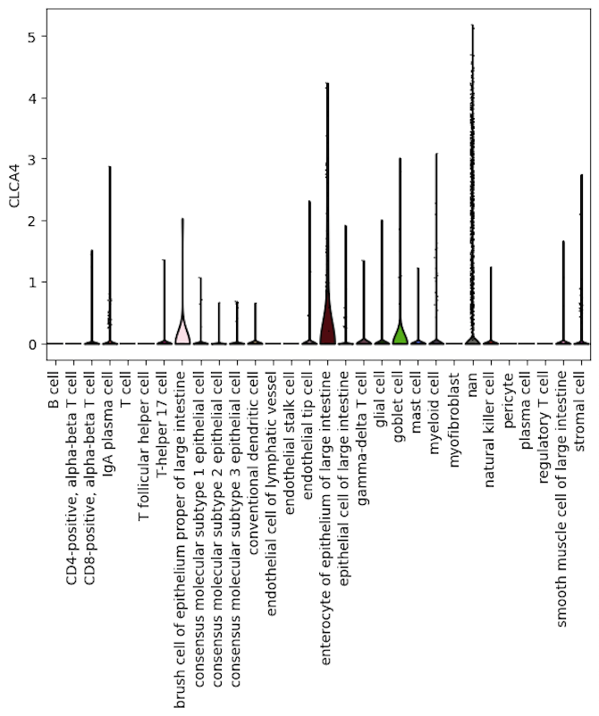

- MS4A1 | plasma cell | B cell

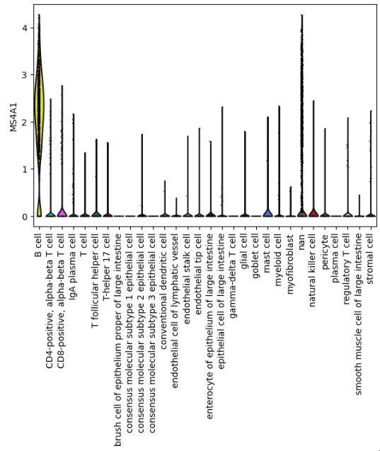

- IGLL5 | plasma cell | plasma

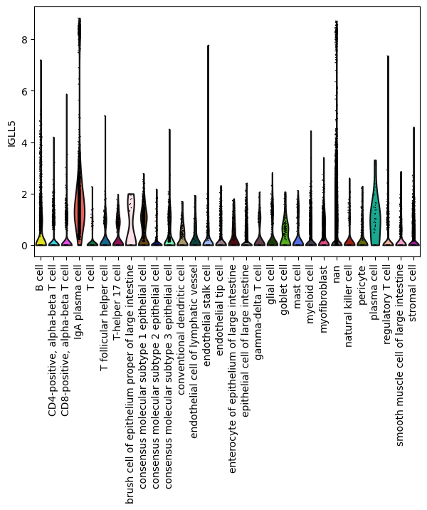

- SLC26A2 | goblet cell | goblet

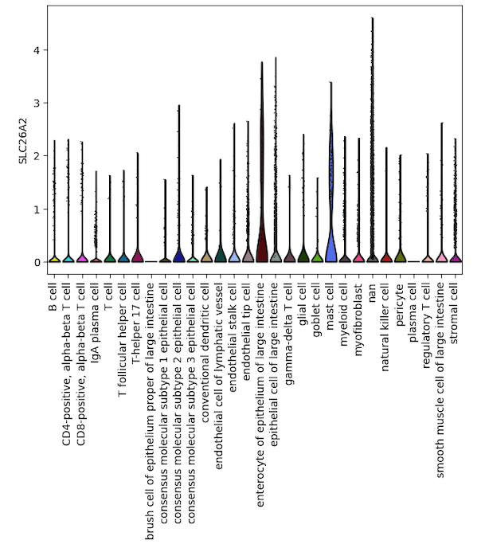